# Biostat 203B Homework 5

Due Mar 22 @ 11:59PM

Author

Jenny Nguyen

## Predicting ICU duration

Using the ICU cohort `mimiciv_icu_cohort.rds` you built in Homework 4, develop at least three machine learning approaches (logistic regression with enet regularization, random forest, boosting, SVM, MLP, etc) plus a model stacking approach for predicting whether a patient’s ICU stay will be longer than 2 days. You should use the `los_long` variable as the outcome. Your algorithms can use patient demographic information (gender, age at ICU `intime`, marital status, race), ICU admission information (first care unit), the last lab measurements before the ICU stay, and first vital measurements during ICU stay as features. You are welcome to use any feature engineering techniques you think are appropriate; but make sure to not use features that are not available at an ICU stay’s `intime`. For instance, `last_careunit` cannot be used in your algorithms.

Load libraries.

```r
library(GGally)
library(gtsummary)
library(tidyverse)
library(tidymodels)
library(glmnet)
library(ranger)
library(xgboost)
library(keras)
library(stacks)
library(vip)
```

1. Data preprocessing and feature engineering.

**Answer:** Read in data and begin preprocessing.

```r
#read in mimic icu cohort data
mimiciv_icu_cohort <- readRDS("mimic_icu_cohort.rds") |>
  #select identifiers, features and outcome to use in algorithm
  select(subject_id, hadm_id, stay_id, first_careunit, marital_status, race,
         gender, intime_age, bicarbonate, potassium, wbc, chloride, hematocrit,
         creatinine, sodium, glucose, non_invasive_blood_pressure_diastolic,
         non_invasive_blood_pressure_systolic, temperature_fahrenheit,
         heart_rate, respiratory_rate, los_long) |>
  #convert first_careunit and race to character, los_long to factor
  mutate(first_careunit = as.character(first_careunit),
         race = as.character(race),
         los_long = as.factor(los_long)) |>
  print(width = Inf)
```

```
# A tibble: 73,181 × 22
   subject_id  hadm_id  stay_id first_careunit
        <int>    <int>    <int> <chr>
 1   10000032 29079034 39553978 Medical Intensive Care Unit (MICU)
 2   10000980 26913865 39765666 Medical Intensive Care Unit (MICU)
 3   10001217 24597018 37067082 Surgical Intensive Care Unit (SICU)
 4   10001217 27703517 34592300 Surgical Intensive Care Unit (SICU)
 5   10001725 25563031 31205490 Medical/Surgical Intensive Care Unit (MICU/SICU)
 6   10001884 26184834 37510196 Medical Intensive Care Unit (MICU)
 7   10002013 23581541 39060235 Cardiac Vascular Intensive Care Unit (CVICU)
 8   10002155 23822395 33685454 Coronary Care Unit (CCU)
 9   10002155 20345487 32358465 Medical Intensive Care Unit (MICU)
10   10002155 28994087 31090461 Medical/Surgical Intensive Care Unit (MICU/SICU)
   marital_status race  gender intime_age bicarbonate potassium   wbc chloride
   <chr>          <chr> <chr>       <int>       <dbl>     <dbl> <dbl>    <dbl>
```

[output cut: 47 more lines]

```r
#check which columns have na values
mimiciv_icu_cohort |>
  map_dbl(~sum(is.na(.)))
```

```
                           subject_id                               hadm_id
                                    0                                     0
                              stay_id                        first_careunit
                                    0                                     0
                       marital_status                                  race
                                 5113                                     0
                               gender                            intime_age
                                    0                                     0
                          bicarbonate                             potassium
                                 9050                                  8901
                                  wbc                              chloride
                                 5094                                  8883
                           hematocrit                            creatinine
                                 5017                                  5770
                               sodium                               glucose
                                 8872                                  9099
non_invasive_blood_pressure_diastolic  non_invasive_blood_pressure_systolic
                                  974                                   970
               temperature_fahrenheit                            heart_rate
                                 1353                                    18
                     respiratory_rate                              los_long
                                   95                                     0
```

Please see step 2 for additional preprocessing and feature engineering. I needed to split the data first before I could preprocess the training set.

2. Partition data into 50% training set and 50% test set. Stratify partitioning according to `los_long`. For grading purpose, sort the data by `subject_id`, `hadm_id`, and `stay_id` and use the seed `203` for the initial data split. Below is the sample code.

**Answer:** Split data into training and test set.

```r
set.seed(203)

# sort
mimiciv_icu_cohort <- mimiciv_icu_cohort |>
  arrange(subject_id, hadm_id, stay_id)

data_split <- initial_split(
  mimiciv_icu_cohort,
  # stratify by los_long
  strata = "los_long",
  prop = 0.5
  )

#split into training and testing
mimic_other <- training(data_split)
mimic_test <- testing(data_split)
```

**Logistic Regression**

Continue to preprocess and feature engineer the training set using recipe.

```r
#recipe
logit_recipe <-
  recipe(
    los_long ~ .,
    data = mimic_other
    ) |>
  #removed identifiers
  step_rm(subject_id, hadm_id, stay_id) |>
  #mean imputation for missing numerical values
  step_impute_mean(bicarbonate, potassium, wbc, chloride, hematocrit, sodium,
                   creatinine, glucose, temperature_fahrenheit, heart_rate,
                   non_invasive_blood_pressure_diastolic,
                   non_invasive_blood_pressure_systolic,
                   respiratory_rate) |>
  #mode imputation for missing categorical values
  step_impute_mode(marital_status) |>
  #create dummy variables
  step_dummy(all_nominal_predictors()) |>
  #zero-variance filter
  step_zv(all_numeric_predictors()) |>
  #center and scale numeric variables
  step_normalize(all_numeric_predictors()) |>
  print()
```

```
── Recipe ──────────────────────────────────────────────────────────────────────
```

```
── Inputs
```

```
Number of variables by role
```

```
outcome:    1
predictor: 21
```

```
── Operations
```

```
• Variables removed: subject_id, hadm_id, stay_id
```

```
• Mean imputation for: bicarbonate, potassium, wbc, chloride, ...
```

```
• Mode imputation for: marital_status
```

```
• Dummy variables from: all_nominal_predictors()
```

```
• Zero variance filter on: all_numeric_predictors()
```

```
• Centering and scaling for: all_numeric_predictors()
```

**Random Forest**

Continue to preprocess and feature engineer the training set using recipe.

```r
#recipe
rf_recipe <-
  recipe(
    los_long ~ .,
    data = mimic_other
    ) |>
  #removed identifiers
  step_rm(subject_id, hadm_id, stay_id) |>
  #mean imputation for missing numerical values
  step_impute_mean(bicarbonate, potassium, wbc, chloride, hematocrit, sodium,
                   creatinine, glucose, temperature_fahrenheit, heart_rate,
                   non_invasive_blood_pressure_diastolic,
                   non_invasive_blood_pressure_systolic,
                   respiratory_rate) |>
  #mode imputation for missing categorical values
  step_impute_mode(marital_status) |>
  #zero-variance filter
  step_zv(all_numeric_predictors()) |>
  print()
```

```
── Recipe ──────────────────────────────────────────────────────────────────────
```

```
── Inputs
```

```
Number of variables by role
```

```
outcome:    1
predictor: 21
```

```
── Operations
```

```
• Variables removed: subject_id, hadm_id, stay_id
```

```
• Mean imputation for: bicarbonate, potassium, wbc, chloride, ...
```

```
• Mode imputation for: marital_status
```

```
• Zero variance filter on: all_numeric_predictors()
```

**Boosting**

Continue to preprocess and feature engineer the training set using recipe.

```r
gb_recipe <-
  recipe(
    los_long ~ .,
    data = mimic_other
    ) |>
  #removed identifiers
  step_rm(subject_id, hadm_id, stay_id) |>
  #mean imputation for missing numerical values
  step_impute_mean(bicarbonate, potassium, wbc, chloride, hematocrit, sodium,
                   creatinine, glucose, temperature_fahrenheit, heart_rate,
                   non_invasive_blood_pressure_diastolic,
                   non_invasive_blood_pressure_systolic,
                   respiratory_rate) |>
  #mode imputation for missing categorical values
  step_impute_mode(marital_status) |>
  #create dummy variables
  step_dummy(all_nominal_predictors()) |>
  #zero-variance filter
  step_zv(all_numeric_predictors()) |>
  print()
```

```
── Recipe ──────────────────────────────────────────────────────────────────────
```

```
── Inputs
```

```
Number of variables by role
```

```
outcome:    1
predictor: 21
```

```
── Operations
```

```
• Variables removed: subject_id, hadm_id, stay_id
```

```
• Mean imputation for: bicarbonate, potassium, wbc, chloride, ...
```

```
• Mode imputation for: marital_status
```

```
• Dummy variables from: all_nominal_predictors()
```

```
• Zero variance filter on: all_numeric_predictors()
```

3. Train and tune the models using the training set.

**Logistic Regression**

**Answer:** Specify the model.

```r
logit_mod <-
  logistic_reg(
    penalty = tune(),
    mixture = tune()
  ) |>
  set_engine("glmnet", standardize = FALSE) |>
  print()
```

```
Logistic Regression Model Specification (classification)

Main Arguments:
  penalty = tune()
  mixture = tune()

Engine-Specific Arguments:
  standardize = FALSE

Computational engine: glmnet
```

Bundle the recipe and model together.

```r
logit_wf <- workflow() |>
  add_recipe(logit_recipe) |>
  add_model(logit_mod) |>
  print()
```

```
══ Workflow ════════════════════════════════════════════════════════════════════
Preprocessor: Recipe
Model: logistic_reg()

── Preprocessor ────────────────────────────────────────────────────────────────
6 Recipe Steps

• step_rm()
• step_impute_mean()
• step_impute_mode()
• step_dummy()
• step_zv()
• step_normalize()

── Model ───────────────────────────────────────────────────────────────────────
Logistic Regression Model Specification (classification)

Main Arguments:
  penalty = tune()
  mixture = tune()

Engine-Specific Arguments:
  standardize = FALSE

Computational engine: glmnet
```

Tune the grid.

```r
logit_param_grid <- grid_regular(
  penalty(range = c(-4, 2)),
  mixture(),
  levels = c(75, 5)
  ) |>
  print()
```

```
# A tibble: 375 × 2
    penalty mixture
      <dbl>   <dbl>
 1 0.0001         0
 2 0.000121       0
 3 0.000145       0
 4 0.000175       0
 5 0.000211       0
 6 0.000254       0
 7 0.000307       0
 8 0.000369       0
 9 0.000445       0
10 0.000537       0
# ℹ 365 more rows
```

Set and fit cross-validation.

```r
#set cross validation partitions
set.seed(203)

folds <- vfold_cv(mimic_other, v = 3)
folds
```

```
#  3-fold cross-validation
# A tibble: 3 × 2
  splits                id
  <list>                <chr>
1 <split [24393/12197]> Fold1
2 <split [24393/12197]> Fold2
3 <split [24394/12196]> Fold3
```

```
# A tibble: 750 × 8
    penalty mixture .metric  .estimator  mean     n std_err
      <dbl>   <dbl> <chr>    <chr>      <dbl> <int>   <dbl>
 1 0.0001         0 accuracy binary     0.582     3 0.00214
 2 0.0001         0 roc_auc  binary     0.610     3 0.00190
 3 0.000121       0 accuracy binary     0.582     3 0.00214
 4 0.000121       0 roc_auc  binary     0.610     3 0.00190
 5 0.000145       0 accuracy binary     0.582     3 0.00214
 6 0.000145       0 roc_auc  binary     0.610     3 0.00190
 7 0.000175       0 accuracy binary     0.582     3 0.00214
 8 0.000175       0 roc_auc  binary     0.610     3 0.00190
 9 0.000211       0 accuracy binary     0.582     3 0.00214
10 0.000211       0 roc_auc  binary     0.610     3 0.00190
   .config
   <chr>
 1 Preprocessor1_Model001
 2 Preprocessor1_Model001
 3 Preprocessor1_Model002
 4 Preprocessor1_Model002
 5 Preprocessor1_Model003
 6 Preprocessor1_Model003
 7 Preprocessor1_Model004
 8 Preprocessor1_Model004
 9 Preprocessor1_Model005
10 Preprocessor1_Model005
# ℹ 740 more rows
```

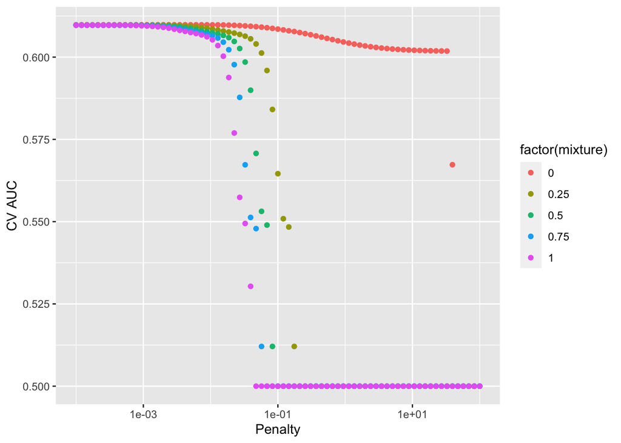

```r
#fit cross validation
logit_fit <- logit_wf |>
  tune_grid(
    resamples = folds,
    grid = logit_param_grid,
    metrics = metric_set(roc_auc, accuracy)
    )

#visualize cross validation results
logit_fit |>
  # aggregate metrics from 5 folds
  collect_metrics() |>
  print(width = Inf) |>
  filter(.metric == "roc_auc") |>
  ggplot(mapping = aes(x = penalty, y = mean, color = factor(mixture))) +
  geom_point() +
  labs(x = "Penalty", y = "CV AUC") +
  scale_x_log10()
```

```r
#show top 5 models
logit_fit |>
  show_best("roc_auc")
```

```
# A tibble: 5 × 8
   penalty mixture .metric .estimator  mean     n std_err .config
     <dbl>   <dbl> <chr>   <chr>      <dbl> <int>   <dbl> <chr>
1 0.0001         0 roc_auc binary     0.610     3 0.00190 Preprocessor1_Model001
2 0.000121       0 roc_auc binary     0.610     3 0.00190 Preprocessor1_Model002
3 0.000145       0 roc_auc binary     0.610     3 0.00190 Preprocessor1_Model003
4 0.000175       0 roc_auc binary     0.610     3 0.00190 Preprocessor1_Model004
5 0.000211       0 roc_auc binary     0.610     3 0.00190 Preprocessor1_Model005
```

```r
#select best model
best_logit <- logit_fit |>
  select_best("roc_auc")
best_logit
```

```
# A tibble: 1 × 3
  penalty mixture .config
    <dbl>   <dbl> <chr>
1  0.0001       0 Preprocessor1_Model001
```

**Random Forest**

**Answer:** Specify the model.

```r
rf_mod <-
  rand_forest(
    mode = "classification",
    mtry = tune(),
    trees = tune()
  ) |>
  set_engine("ranger", importance = "impurity") |>
  print()
```

```
Random Forest Model Specification (classification)

Main Arguments:
  mtry = tune()
  trees = tune()

Engine-Specific Arguments:
  importance = impurity

Computational engine: ranger
```

Bundle the recipe and model together.

```r
rf_wf <- workflow() |>
  add_recipe(rf_recipe) |>
  add_model(rf_mod) |>
  print()
```

```
══ Workflow ════════════════════════════════════════════════════════════════════
Preprocessor: Recipe
Model: rand_forest()

── Preprocessor ────────────────────────────────────────────────────────────────
4 Recipe Steps

• step_rm()
• step_impute_mean()
• step_impute_mode()
• step_zv()

── Model ───────────────────────────────────────────────────────────────────────
Random Forest Model Specification (classification)

Main Arguments:
  mtry = tune()
  trees = tune()

Engine-Specific Arguments:
  importance = impurity

Computational engine: ranger
```

Tune the grid.

```r
rf_param_grid <- grid_regular(
  trees(range = c(50L, 150L)),
  mtry(range = c(1L, 5L)),
  levels = c(3, 5)
  ) |>
  print()
```

```
# A tibble: 15 × 2
   trees  mtry
   <int> <int>
 1    50     1
 2   100     1
 3   150     1
 4    50     2
 5   100     2
 6   150     2
 7    50     3
 8   100     3
 9   150     3
10    50     4
11   100     4
12   150     4
13    50     5
14   100     5
15   150     5
```

Set and fit cross-validation.

```r
#set cross validation partitions
set.seed(203)

folds <- vfold_cv(mimic_other, v = 3)
folds
```

```
#  3-fold cross-validation
# A tibble: 3 × 2
  splits                id
  <list>                <chr>
1 <split [24393/12197]> Fold1
2 <split [24393/12197]> Fold2
3 <split [24394/12196]> Fold3
```

```
# A tibble: 30 × 8
    mtry trees .metric  .estimator  mean     n  std_err .config
   <int> <int> <chr>    <chr>      <dbl> <int>    <dbl> <chr>
 1     1    50 accuracy binary     0.583     3 0.00482  Preprocessor1_Model01
 2     1    50 roc_auc  binary     0.617     3 0.00404  Preprocessor1_Model01
 3     1   100 accuracy binary     0.591     3 0.00279  Preprocessor1_Model02
 4     1   100 roc_auc  binary     0.628     3 0.00349  Preprocessor1_Model02
 5     1   150 accuracy binary     0.592     3 0.00309  Preprocessor1_Model03
 6     1   150 roc_auc  binary     0.632     3 0.00377  Preprocessor1_Model03
 7     2    50 accuracy binary     0.588     3 0.00109  Preprocessor1_Model04
 8     2    50 roc_auc  binary     0.622     3 0.000750 Preprocessor1_Model04
 9     2   100 accuracy binary     0.591     3 0.000406 Preprocessor1_Model05
10     2   100 roc_auc  binary     0.630     3 0.00250  Preprocessor1_Model05
# ℹ 20 more rows
```

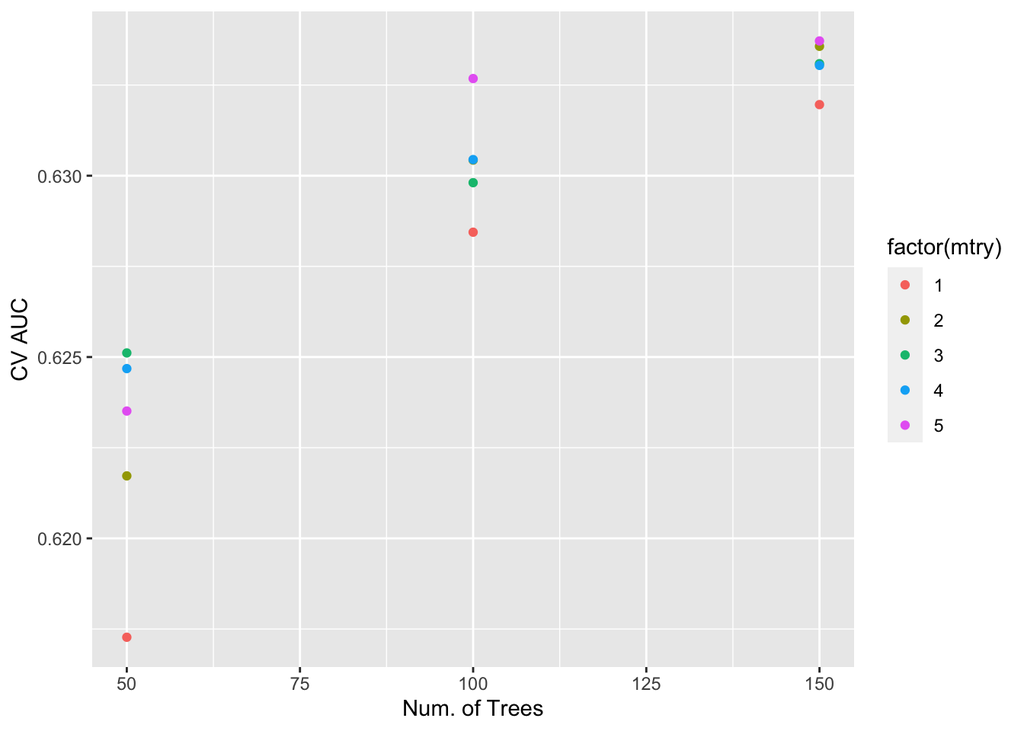

```r
#fit cross validation
rf_fit <- rf_wf |>
  tune_grid(
    resamples = folds,
    grid = rf_param_grid,
    metrics = metric_set(roc_auc, accuracy)
    )

#visualize cross validation results
rf_fit |>
  collect_metrics() |>
  print(width = Inf) |>
  filter(.metric == "roc_auc") |>
  ggplot(mapping = aes(x = trees, y = mean, color = factor(mtry))) +
  geom_point() +
  labs(x = "Num. of Trees", y = "CV AUC")
```

```r
#show top 5 models
rf_fit |>
  show_best("roc_auc")
```

```
# A tibble: 5 × 8
   mtry trees .metric .estimator  mean     n std_err .config
  <int> <int> <chr>   <chr>      <dbl> <int>   <dbl> <chr>
1     5   150 roc_auc binary     0.634     3 0.00136 Preprocessor1_Model15
2     2   150 roc_auc binary     0.634     3 0.00286 Preprocessor1_Model06
3     3   150 roc_auc binary     0.633     3 0.00239 Preprocessor1_Model09
4     4   150 roc_auc binary     0.633     3 0.00223 Preprocessor1_Model12
5     5   100 roc_auc binary     0.633     3 0.00191 Preprocessor1_Model14
```

```r
#select best model
best_rf <- rf_fit |>
  select_best("roc_auc")
best_rf
```

```
# A tibble: 1 × 3
   mtry trees .config
  <int> <int> <chr>
1     5   150 Preprocessor1_Model15
```

**Boosting**

**Answer:** Specify the model.

```r
gb_mod <-
  boost_tree(
    mode = "classification",
    trees = 500,
    tree_depth = tune(),
    learn_rate = tune()
  ) |>
  set_engine("xgboost") |>
  print()
```

```
Boosted Tree Model Specification (classification)

Main Arguments:
  trees = 500
  tree_depth = tune()
  learn_rate = tune()

Computational engine: xgboost
```

Bundle the recipe and model together.

```r
gb_wf <- workflow() |>
  add_recipe(gb_recipe) |>
  add_model(gb_mod) |>
  print()
```

```
══ Workflow ════════════════════════════════════════════════════════════════════
Preprocessor: Recipe
Model: boost_tree()

── Preprocessor ────────────────────────────────────────────────────────────────
5 Recipe Steps

• step_rm()
• step_impute_mean()
• step_impute_mode()
• step_dummy()
• step_zv()

── Model ───────────────────────────────────────────────────────────────────────
Boosted Tree Model Specification (classification)

Main Arguments:
  trees = 500
  tree_depth = tune()
  learn_rate = tune()

Computational engine: xgboost
```

Tune the grid.

```r
gb_param_grid <- grid_regular(
  tree_depth(range = c(1L, 3L)),
  learn_rate(range = c(-5, 2), trans = log10_trans()),
  levels = c(3, 5)
  ) |>
  print()
```

```
# A tibble: 15 × 2
   tree_depth learn_rate
        <int>      <dbl>
 1          1   0.00001
 2          2   0.00001
 3          3   0.00001
 4          1   0.000562
 5          2   0.000562
 6          3   0.000562
 7          1   0.0316
 8          2   0.0316
 9          3   0.0316
10          1   1.78
11          2   1.78
12          3   1.78
13          1 100
14          2 100
15          3 100
```

Set and fit cross-validation.

```r
#set cross validation partitions
set.seed(203)

folds <- vfold_cv(mimic_other, v = 3)
folds
```

```
#  3-fold cross-validation
# A tibble: 3 × 2
  splits                id
  <list>                <chr>
1 <split [24393/12197]> Fold1
2 <split [24393/12197]> Fold2
3 <split [24394/12196]> Fold3
```

```r
#fit cross validation
gb_fit <- gb_wf |>
  tune_grid(
    resamples = folds,
    grid = gb_param_grid,
    metrics = metric_set(roc_auc, accuracy)
    )
gb_fit
```

```
# Tuning results
# 3-fold cross-validation
# A tibble: 3 × 4
  splits                id    .metrics          .notes
  <list>                <chr> <list>            <list>
1 <split [24393/12197]> Fold1 <tibble [30 × 6]> <tibble [0 × 3]>
2 <split [24393/12197]> Fold2 <tibble [30 × 6]> <tibble [0 × 3]>
3 <split [24394/12196]> Fold3 <tibble [30 × 6]> <tibble [0 × 3]>
```

```
# A tibble: 30 × 8
   tree_depth learn_rate .metric  .estimator  mean     n  std_err
        <int>      <dbl> <chr>    <chr>      <dbl> <int>    <dbl>
 1          1   0.00001  accuracy binary     0.538     3 0.00505
 2          1   0.00001  roc_auc  binary     0.525     3 0.00441
 3          2   0.00001  accuracy binary     0.547     3 0.00394
 4          2   0.00001  roc_auc  binary     0.548     3 0.000467
 5          3   0.00001  accuracy binary     0.553     3 0.00824
 6          3   0.00001  roc_auc  binary     0.562     3 0.000970
 7          1   0.000562 accuracy binary     0.548     3 0.00607
 8          1   0.000562 roc_auc  binary     0.571     3 0.00621
 9          2   0.000562 accuracy binary     0.562     3 0.00590
10          2   0.000562 roc_auc  binary     0.585     3 0.00572
   .config
   <chr>
 1 Preprocessor1_Model01
 2 Preprocessor1_Model01
 3 Preprocessor1_Model02
 4 Preprocessor1_Model02
 5 Preprocessor1_Model03
 6 Preprocessor1_Model03
 7 Preprocessor1_Model04
 8 Preprocessor1_Model04
 9 Preprocessor1_Model05
10 Preprocessor1_Model05
# ℹ 20 more rows
```

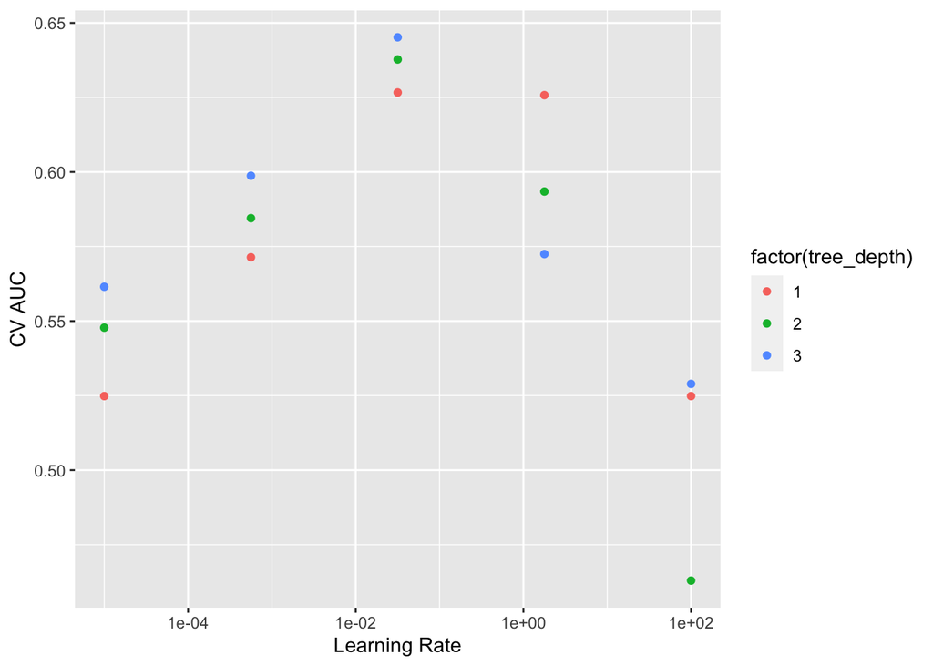

```r
#visualize cross validation results
gb_fit |>
  collect_metrics() |>
  print(width = Inf) |>
  filter(.metric == "roc_auc") |>
  ggplot(mapping = aes(x = learn_rate, y = mean, color = factor(tree_depth))) +
  geom_point() +
  labs(x = "Learning Rate", y = "CV AUC") +
  scale_x_log10()
```

```r
#show top 5 models
gb_fit |>
  show_best("roc_auc")
```

```
# A tibble: 5 × 8
  tree_depth learn_rate .metric .estimator  mean     n std_err .config
       <int>      <dbl> <chr>   <chr>      <dbl> <int>   <dbl> <chr>
1          3   0.0316   roc_auc binary     0.645     3 0.00167 Preprocessor1_Mo…
2          2   0.0316   roc_auc binary     0.638     3 0.00302 Preprocessor1_Mo…
3          1   0.0316   roc_auc binary     0.627     3 0.00306 Preprocessor1_Mo…
4          1   1.78     roc_auc binary     0.626     3 0.00347 Preprocessor1_Mo…
5          3   0.000562 roc_auc binary     0.599     3 0.00433 Preprocessor1_Mo…
```

```r
#select best model
best_gb <- gb_fit |>
  select_best("roc_auc")
best_gb
```

```
# A tibble: 1 × 3
  tree_depth learn_rate .config
       <int>      <dbl> <chr>
1          3     0.0316 Preprocessor1_Model09
```

4. Compare model classification performance on the test set. Report both the area under ROC curve and accuracy for each machine learning algorithm and the model stacking. Interpret the results. What are the most important features in predicting long ICU stays? How do the models compare in terms of performance and interpretability?

**Logistic Regression**

**Answer:** Finalize the model.

```r
#final workflow
logit_final_wf <- logit_wf |>
  finalize_workflow(best_logit)
logit_final_wf
```

```
══ Workflow ════════════════════════════════════════════════════════════════════
Preprocessor: Recipe
Model: logistic_reg()

── Preprocessor ────────────────────────────────────────────────────────────────
6 Recipe Steps

• step_rm()
• step_impute_mean()
• step_impute_mode()
• step_dummy()
• step_zv()
• step_normalize()

── Model ───────────────────────────────────────────────────────────────────────
Logistic Regression Model Specification (classification)

Main Arguments:
  penalty = 1e-04
  mixture = 0

Engine-Specific Arguments:
  standardize = FALSE

Computational engine: glmnet
```

```r
#fit the whole training set, then predict test set
logit_final_fit <-
  logit_final_wf |>
  last_fit(data_split)
logit_final_fit
```

```
# Resampling results
# Manual resampling
# A tibble: 1 × 6
  splits                id             .metrics .notes   .predictions .workflow
  <list>                <chr>          <list>   <list>   <list>       <list>
1 <split [36590/36591]> train/test sp… <tibble> <tibble> <tibble>     <workflow>
```

```r
#test metrics
logit_final_fit |>
  collect_metrics()
```

```
# A tibble: 2 × 4
  .metric  .estimator .estimate .config
  <chr>    <chr>          <dbl> <chr>
1 accuracy binary         0.577 Preprocessor1_Model1
2 roc_auc  binary         0.599 Preprocessor1_Model1
```

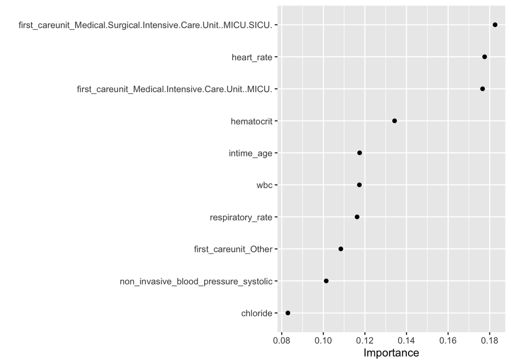

```r
#extract model coefficients
logit_final_wf |>
  fit(mimic_other) |>
  extract_fit_parsnip() |>
  vip(geom = "point")
```

The logistic regression model has an AUC of 0.599 and an accuracy of 0.577. Both the AUC and accuracy are close to 0.50, indicating that the model is not very good at predicting long ICU stays. In this model, the most important features in predicting long ICU stays are `heart_rate` and if the patient’s `first_careunit` is MICU or MICU/SICU because they have the highest importance scores according to the variables of importance plot above.

**Random Forest**

**Answer:** Finalize the model.

```r
#final workflow
rf_final_wf <- rf_wf |>
  finalize_workflow(best_rf)
rf_final_wf
```

```
══ Workflow ════════════════════════════════════════════════════════════════════
Preprocessor: Recipe
Model: rand_forest()

── Preprocessor ────────────────────────────────────────────────────────────────
4 Recipe Steps

• step_rm()
• step_impute_mean()
• step_impute_mode()
• step_zv()

── Model ───────────────────────────────────────────────────────────────────────
Random Forest Model Specification (classification)

Main Arguments:
  mtry = 5
  trees = 150

Engine-Specific Arguments:
  importance = impurity

Computational engine: ranger
```

```r
#fit the whole training set, then predict test set
rf_final_fit <-
  rf_final_wf |>
  last_fit(data_split)
rf_final_fit
```

```
# Resampling results
# Manual resampling
# A tibble: 1 × 6
  splits                id             .metrics .notes   .predictions .workflow
  <list>                <chr>          <list>   <list>   <list>       <list>
1 <split [36590/36591]> train/test sp… <tibble> <tibble> <tibble>     <workflow>
```

```r
#test metrics
rf_final_fit |>
  collect_metrics()
```

```
# A tibble: 2 × 4
  .metric  .estimator .estimate .config
  <chr>    <chr>          <dbl> <chr>
1 accuracy binary         0.599 Preprocessor1_Model1
2 roc_auc  binary         0.634 Preprocessor1_Model1
```

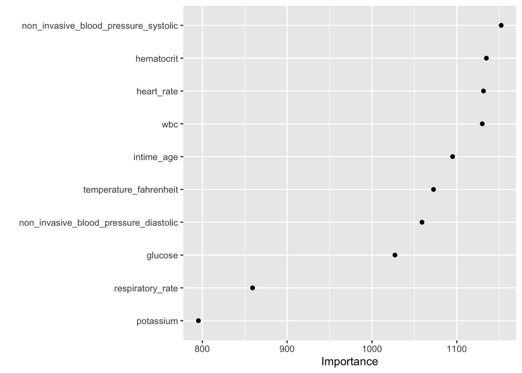

```r
#identify variables of importance
rf_final_wf |>
  fit(mimic_other) |>
  extract_fit_parsnip() |>
  vip(geom = "point")
```

The random forest model has an AUC of 0.634 and an accuracy of 0.599. Both the AUC and accuracy from the random forest model are higher than the AUC and accuracy from the logistic regression model, indicating that the random forest model is better at predicting long ICU stays than the logistic regression model. In this model, the most important features in predicting long ICU stays are `non_invasive_blood_pressure_systolic`, `heart_rate`, and `hematocrit` because they have the highest importance scores according to the variables of importance plot above.

**Boosting**

**Answer:** Finalize the model.

```r
#final workflow
gb_final_wf <- gb_wf |>
  finalize_workflow(best_gb)
gb_final_wf
```

```
══ Workflow ════════════════════════════════════════════════════════════════════
Preprocessor: Recipe
Model: boost_tree()

── Preprocessor ────────────────────────────────────────────────────────────────
5 Recipe Steps

• step_rm()
• step_impute_mean()
• step_impute_mode()
• step_dummy()
• step_zv()

── Model ───────────────────────────────────────────────────────────────────────
Boosted Tree Model Specification (classification)

Main Arguments:
  trees = 500
  tree_depth = 3
  learn_rate = 0.0316227766016838

Computational engine: xgboost
```

```r
#fit the whole training set, then predict test set
gb_final_fit <-
  gb_final_wf |>
  last_fit(data_split)
gb_final_fit
```

```
# Resampling results
# Manual resampling
# A tibble: 1 × 6
  splits                id             .metrics .notes   .predictions .workflow
  <list>                <chr>          <list>   <list>   <list>       <list>
1 <split [36590/36591]> train/test sp… <tibble> <tibble> <tibble>     <workflow>
```

```r
#test metrics
gb_final_fit |>
  collect_metrics()
```

```
# A tibble: 2 × 4
  .metric  .estimator .estimate .config
  <chr>    <chr>          <dbl> <chr>
1 accuracy binary         0.605 Preprocessor1_Model1
2 roc_auc  binary         0.646 Preprocessor1_Model1
```

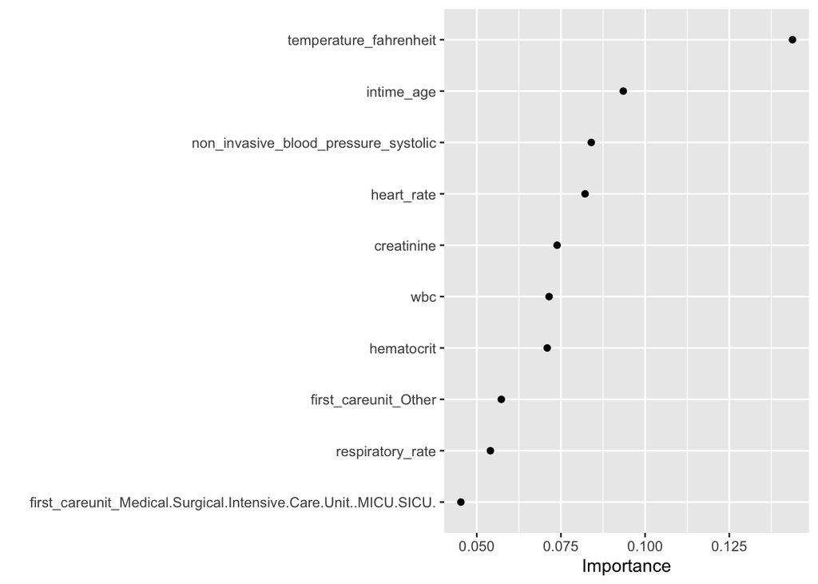

```r
#identify variables of importance
gb_final_wf |>
  fit(mimic_other) |>
  extract_fit_parsnip() |>
  vip(geom = "point")
```

The boosting model has an AUC of 0.646 and an accuracy of 0.605. Both the AUC and accuracy from the boosting model are higher than the AUC and accuracy from the logistic regression model and the random forest model, indicating that the boosting model is better at predicting long ICU stays than the other two models. In this model, the most important features in predicting long ICU stays are `temperature_fahrenheit`, `intime_age`, and `non_invasive_blood_pressure_systolic` because they have the highest importance scores according to the variables of importance plot above.

## Model Stacking

**Answer:** Set up tuning grid for the stacked model.

```r
logit_res <-
  tune_grid(
    object = logit_wf,
    resamples = folds,
    grid = logit_param_grid,
    control = control_stack_grid()
  )
```

```
ℹ The workflow being saved contains a recipe, which is 5.52 Mb in ℹ memory. If
this was not intentional, please set the control setting ℹ `save_workflow =
FALSE`.
```

```r
logit_res
```

```
# Tuning results
# 3-fold cross-validation
# A tibble: 3 × 5
  splits                id    .metrics           .notes           .predictions
  <list>                <chr> <list>             <list>           <list>
1 <split [24393/12197]> Fold1 <tibble [750 × 6]> <tibble [0 × 3]> <tibble>
2 <split [24393/12197]> Fold2 <tibble [750 × 6]> <tibble [0 × 3]> <tibble>
3 <split [24394/12196]> Fold3 <tibble [750 × 6]> <tibble [0 × 3]> <tibble>
```

```r
rf_res <-
  tune_grid(
    object = rf_wf,
    resamples = folds,
    grid = rf_param_grid,
    control = control_stack_grid()
  )
```

```
ℹ The workflow being saved contains a recipe, which is 5.49 Mb in ℹ memory. If
this was not intentional, please set the control setting ℹ `save_workflow =
FALSE`.
```

```r
rf_res
```

```
# Tuning results
# 3-fold cross-validation
# A tibble: 3 × 5
  splits                id    .metrics          .notes           .predictions
  <list>                <chr> <list>            <list>           <list>
1 <split [24393/12197]> Fold1 <tibble [30 × 6]> <tibble [0 × 3]> <tibble>
2 <split [24393/12197]> Fold2 <tibble [30 × 6]> <tibble [0 × 3]> <tibble>
3 <split [24394/12196]> Fold3 <tibble [30 × 6]> <tibble [0 × 3]> <tibble>
```

```r
gb_res <-
  tune_grid(
    object = gb_wf,
    resamples = folds,
    grid = gb_param_grid,
    control = control_stack_grid()
  )
```

```
ℹ The workflow being saved contains a recipe, which is 5.52 Mb in ℹ memory. If
this was not intentional, please set the control setting ℹ `save_workflow =
FALSE`.
```

```r
gb_res
```

```
# Tuning results
# 3-fold cross-validation
# A tibble: 3 × 5
  splits                id    .metrics          .notes           .predictions
  <list>                <chr> <list>            <list>           <list>
1 <split [24393/12197]> Fold1 <tibble [30 × 6]> <tibble [0 × 3]> <tibble>
2 <split [24393/12197]> Fold2 <tibble [30 × 6]> <tibble [0 × 3]> <tibble>
3 <split [24394/12196]> Fold3 <tibble [30 × 6]> <tibble [0 × 3]> <tibble>
```

Build the stacked ensemble.

```r
mimic_model_st <-
  #initialize the stack
  stacks() |>
  #add candidate members
  add_candidates(logit_res) |>
  add_candidates(rf_res) |>
  add_candidates(gb_res) |>
  #determine how to combine their predictions
  blend_predictions(
    metrics = c("roc_auc")
    ) |>
  #fit the candidates with nonzero stacking coefficients
  fit_members()
mimic_model_st
```

```
── A stacked ensemble model ─────────────────────────────────────


Out of 193 possible candidate members, the ensemble retained 18.

Penalty: 1e-06.

Mixture: 1.


The 10 highest weighted member classes are:
```

```
# A tibble: 10 × 3
   member                     type         weight
   <chr>                      <chr>         <dbl>
 1 .pred_TRUE_gb_res_1_09     boost_tree    1.65
 2 .pred_TRUE_gb_res_1_10     boost_tree    0.680
 3 .pred_TRUE_rf_res_1_09     rand_forest   0.559
 4 .pred_TRUE_rf_res_1_06     rand_forest   0.454
 5 .pred_TRUE_rf_res_1_08     rand_forest   0.395
 6 .pred_TRUE_rf_res_1_11     rand_forest   0.368
 7 .pred_TRUE_logit_res_1_001 logistic_reg  0.297
 8 .pred_TRUE_rf_res_1_04     rand_forest   0.281
 9 .pred_TRUE_rf_res_1_10     rand_forest   0.243
10 .pred_TRUE_rf_res_1_05     rand_forest   0.141
```

Plot results.

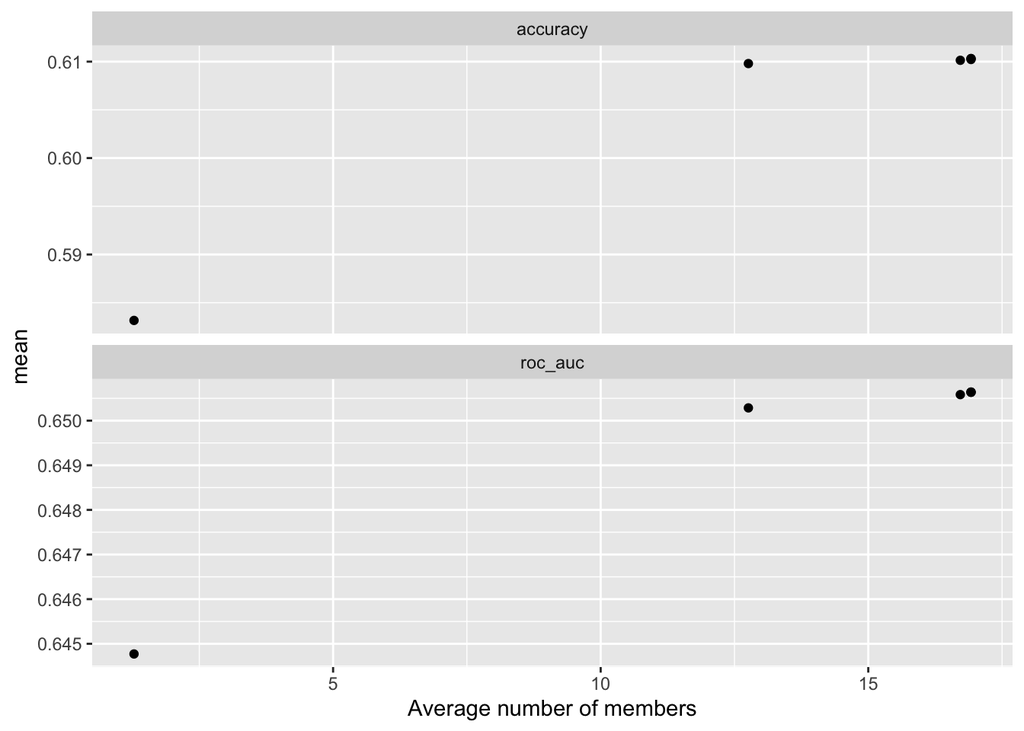

```r
autoplot(mimic_model_st, type = "members")
```

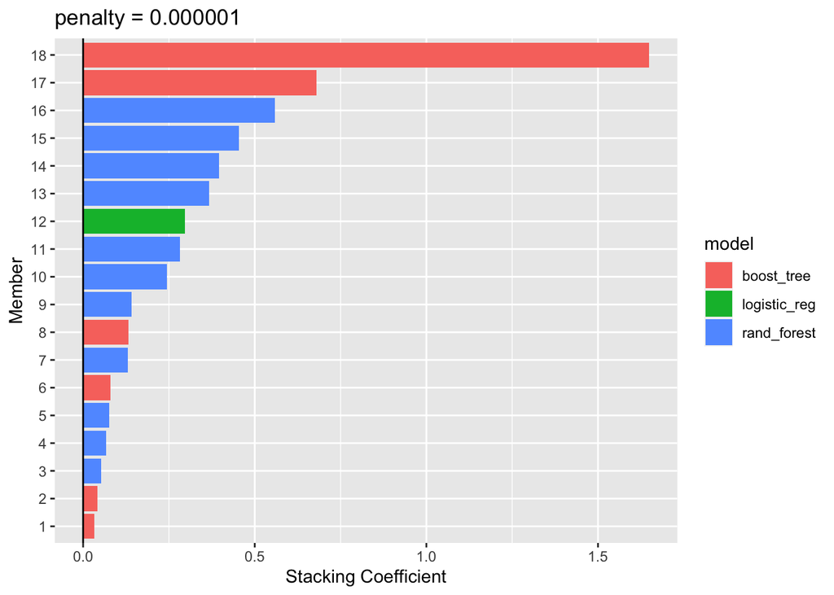

```r
#top results
autoplot(mimic_model_st, type = "weights")
```

Complete the final classification.

```r
mimic_pred <- mimic_test |>
  bind_cols(predict(mimic_model_st, mimic_test, type = "prob")) |>
  print(width = Inf)
```

```
# A tibble: 36,591 × 24
   subject_id  hadm_id  stay_id first_careunit
        <int>    <int>    <int> <chr>
 1   10000032 29079034 39553978 Medical Intensive Care Unit (MICU)
 2   10001217 24597018 37067082 Surgical Intensive Care Unit (SICU)
 3   10001217 27703517 34592300 Surgical Intensive Care Unit (SICU)
 4   10001725 25563031 31205490 Medical/Surgical Intensive Care Unit (MICU/SICU)
 5   10002013 23581541 39060235 Cardiac Vascular Intensive Care Unit (CVICU)
 6   10002155 23822395 33685454 Coronary Care Unit (CCU)
 7   10002428 28662225 33987268 Medical Intensive Care Unit (MICU)
 8   10002428 28662225 38875437 Medical Intensive Care Unit (MICU)
 9   10002430 26295318 38392119 Coronary Care Unit (CCU)
10   10002495 24982426 36753294 Coronary Care Unit (CCU)
   marital_status race  gender intime_age bicarbonate potassium   wbc chloride
   <chr>          <chr> <chr>       <int>       <dbl>     <dbl> <dbl>    <dbl>
```

[output cut: 47 more lines]

```r
#compute roc auc for model
yardstick::roc_auc(
  mimic_pred,
  truth = los_long,
  contains(".pred_FALSE")
  )
```

```
# A tibble: 1 × 3
  .metric .estimator .estimate
  <chr>   <chr>          <dbl>
1 roc_auc binary         0.651
```

```r
#generate predictions from ensemble members
mimic_pred <-
  mimic_test |>
  select(los_long) |>
  bind_cols(
    predict(
      mimic_model_st,
      mimic_test,
      type = "class",
      members = TRUE
      )
    ) |>
  print(width = Inf)
```

```
# A tibble: 36,591 × 20
   los_long .pred_class .pred_class_logit_res_1_001 .pred_class_rf_res_1_02
   <fct>    <fct>       <fct>                       <fct>
 1 FALSE    FALSE       FALSE                       FALSE
 2 FALSE    FALSE       FALSE                       FALSE
 3 FALSE    FALSE       FALSE                       FALSE
 4 FALSE    TRUE        FALSE                       FALSE
 5 FALSE    FALSE       FALSE                       FALSE
 6 TRUE     FALSE       FALSE                       FALSE
 7 TRUE     TRUE        TRUE                        TRUE
 8 TRUE     TRUE        FALSE                       FALSE
 9 TRUE     FALSE       TRUE                        FALSE
10 TRUE     TRUE        TRUE                        TRUE
   .pred_class_rf_res_1_04 .pred_class_rf_res_1_05 .pred_class_rf_res_1_06
   <fct>                   <fct>                   <fct>
```

[output cut: 71 more lines]

```r
#compute accuracy for model
yardstick::accuracy(
  mimic_pred,
  truth = los_long,
  estimate = .pred_class
  )
```

```
# A tibble: 1 × 3
  .metric  .estimator .estimate
  <chr>    <chr>          <dbl>
1 accuracy binary         0.610
```

The ensemble model has an AUC of 0.651 and an accuracy of 0.610. Both the AUC and accuracy from the ensemble model are higher than the AUC and accuracy from all other three individual models, indicating that the ensemble model is the best at predicting long ICU stays.

In terms of performance, the ensemble model performed the best out of all the models as it had the highest AUC. The boosting model performed the second best, followed by the random forest model, and then finally the logistic regression model, which had the lowest AUC. These results make sense because typically, combining multiple models into an ensemble model will provide the best model, and thus, performance.

In terms of interpretability, the logistic regression model is the most interpretable because the coefficients of a logistic regression model can clearly convey both the effect size and direction of the features on the outcome. Thus, it’s easy to understand how increasing or decreasing a feature will impact the outcome. The random forest and boosting models are both less interpretable because they involve averaging predictions from multiple decision trees, which makes it less intuitive to understand how certain features impact the outcome. The ensemble model is probably the least interpretable because it combines all three models into one, making it even more difficult to understand how certain features impact the outcome.

Based off of assessing both the performance and interpretability of the models, we can see that there is a trade-off between maximizing performance and maximizing interpretability.